# Informe_Final

Johanna Vinueza, Erika Neira

2023-08-05

## Proyecto final del módulo - Introducción a programación en R

### Introducción

La liquidez y la solvencia son indicadores críticos que brindan una visión clave sobre la capacidad financiera de una organización. Tanto para empresas, inversionistas y analistas, estos indicadores son fundamentales para comprender cómo una empresa puede afrontar sus obligaciones financieras y mantener una operación sostenible a lo largo del tiempo.

La liquidez se enfoca en medir la capacidad de la empresa para convertir sus activos en efectivo y cumplir con sus pasivos a corto plazo. Por otro lado, la solvencia se refiere a la capacidad de la empresa para hacer frente a sus deudas a largo plazo.

Al analizar estos indicadores, obtenemos una visión integral sobre la habilidad de la compañía para cumplir con sus obligaciones tanto en el corto como en el largo plazo, y también para mantener su operatividad a lo largo del tiempo.

Para realizar este análisis, utilizaremos el lenguaje de programación R, lo que nos permitirá estudiar diferentes variables financieras, tamaño, número de empleados, provincia, cantón, ciudad, actividad económica, entre otras, de un grupo de empresas. De esta manera, obtendremos una visión holística de la situación financiera de estas compañías y comprenderemos mejor su posición en el mercado.

Mediante este proyecto, podremos tomar decisiones informadas sobre las empresas analizadas y evaluar su desempeño financiero con una perspectiva más amplia. La combinación de estos indicadores con el análisis detallado de diversas variables nos brindará una visión más completa y precisa sobre la salud financiera de las empresas en cuestión.

### Objetivo

Nuestro objetivo es promover el conocimiento y la comprensión en el ámbito financiero, proporcionando información relevante a inversionistas, directivos y a todas aquellas personas interesadas en conocer la situación financiera de las empresas ecuatorianas que estamos estudiando. Además, este proyecto tiene como propósito fomentar el desarrollo de habilidades analíticas y de programación en R entre las becarias, para que puedan destacarse en el competitivo mundo financiero y empresarial.

### Descripción de los datos

La base de datos que analizaremos contiene datos públicos proporcionados por la Autoridad competente en Ecuador, la Superintendencia de Compañías. Estos datos son de carácter público y accesibles para todos, lo que permite un análisis transparente y objetivo de la información financiera de las empresas registradas en el país.

El uso de datos proporcionados por la Superintendencia de Compañías garantiza la confiabilidad y la precisión de la información, ya que es recopilada y verificada por una entidad oficial y reguladora. Esto asegura que los resultados obtenidos a partir del análisis de esta base de datos sean sólidos y confiables.

Esta base de datos, contiene información clave sobre cuentas contables y variables, facilitando el análisis financiero. Cada empresa está identificada por un registro único de contribuyentes, lo que proporciona una visión rápida de su estado operativo. Además, se detalla el tipo de compañía, permitiendo su clasificación según su naturaleza jurídica y actividad comercial. También se incluye la fecha de constitución, lo que ayuda a rastrear su tiempo de existencia.

Para brindar una visión más completa, la base de datos contiene datos geográficos precisos, como la ubicación de la sede principal en provincia, cantón y ciudad. Además, se ha categorizado el nivel de la empresa, proporcionando información sobre su tamaño y alcance.

### Análisis

**Parte 1 - Data** Para el análisis de datos se cargaron los siguentes paquetes: # Paquetes y librerias—-

```r
paquetes <- c("openxlsx", "magrittr", "tidyverse", "readr", "dplyr", "readxl")
lapply(paquetes, library, character.only = TRUE)
```

[output not shown]

```r
tinytex::install_tinytex(force = TRUE)

balance_2014_df<-read.xlsx("Data/balances_2014.xlsx")
ciiu_table<-read.xlsx("Data/ciiu.xlsx")%>% view("ciuu")
ciiu_df2<-tibble::as_tibble(ciiu_table)
```

Para la realización de las tareas específicas, se tuvo que cargar 2 bases principales: balance_2014 y ciiu. En la obtención del tibble denominado empresas se procedió de la siguiente manera: 1. Con el fin de evitar divisiones entre cero (indeterminaciones) en el cálculo de los indicadores de liquidez y solvencia filtramos los datos contenidos en aquellas variables, tomando solamente valores estrictos mayores que cero. Cabe mencionar que que los valores que no cumplian con estas condiciones los eliminabamos de la base de datos obteniendo así una base más compacta de alrededor de 29.286 de la data inicial. Lo cual continua siendo una data adecuada para sus respectivos análisis. Empleamos el siguiente código

```r
balance_2014_filter<-balance_2014_df %>%
mutate(v539=ifelse(v539>0, v539, NA), v599=ifelse(v599>0, v599, NA),
       v698=ifelse(v698>0, v698, NA), v498=ifelse(v498>0, v498, NA)) %>%
filter(!is.na(v539) & !is.na(v599) & !is.na(v698) & !is.na(v498)) %>%
  view("balance_2014_filter")
```

Una vez con realizados estos cambios, se procedió con la construcción del objeto denominado empresas como tibble. Para esta tarea fue esencial las funciones como mutate y transmutate. Como puede apreciar se iban añadiendo las variables solicitadas

```r
empresas_df1<-balance_2014_filter %>% transmute(Empresas= nombre_cia, Status= situacion,
Tipo_de_empresa=tipo,País= pais, Provincia=provincia, Canton=canton, Ciudad= ciudad,
Actividad_economica= ciiu4_nivel1, Subactividad=ciiu4_nivel6,
Liquidez_Corriente= v345/v539, Endeudamiento_activo= v599/v499  ,
Endeudamiento_patrimonial= v599/v698, Endeudamiento_activo_fijo= v698/v498 ,
Apalancamiento= v499/v698) %>% view("empresas_df1")
```

Sin embargo, las variables denominadas Actividad_económica y subactividad necesitaban estar explicitamente con una descripción en base a su codificación por lo que usando inner_join y mutate podimos realizar aquella solicitud. El código se muestra a continuación

```r
empresas_subac<-empresas_df1 %>% inner_join(ciiu_df2, by = c("Subactividad"="CODIGO"))%>%
mutate(Subactividad=DESCRIPCION) %>% select(-c(DESCRIPCION, NIVEL)) %>%
view("change_Subac")

empresas_final<-empresas_subac %>%
inner_join(ciiu_df2, by = c("Actividad_economica"="CODIGO")) %>%
mutate(Actividad_economica=DESCRIPCION) %>%
select(-c(DESCRIPCION, NIVEL)) %>% view("final_table")
```

Finalmente, nos toca convertir al objeto empresas_final el cual contiene todas las variables solicitadas en un tibble.

```r
empresas<-tibble::as_tibble(empresas_final) %>% view("empresas")
glimpse(empresas)
```

```
## Rows: 29,243
## Columns: 14
## $ Empresas                  <chr> "ACEITES TROPICALES SOCIEDAD ANONIMA ATSA", …
## $ Status                    <chr> "ACTIVA", "ACTIVA", "ACTIVA", "ACTIVA", "ACT…
## $ Tipo_de_empresa           <chr> "ANÓNIMA", "ANÓNIMA", "ANÓNIMA", "ANÓNIMA", …
## $ País                      <chr> "ECUADOR", "ECUADOR", "ECUADOR", "ECUADOR", …
## $ Provincia                 <chr> "SANTO DOMINGO DE LOS TSACHILAS", "PICHINCHA…
## $ Canton                    <chr> "SANTO DOMINGO", "QUITO", "QUITO", "QUITO", …
## $ Ciudad                    <chr> "SANTO DOMINGO", "QUITO", "QUITO", "QUITO", …
## $ Actividad_economica       <chr> "AGRICULTURA, GANADERÍA,  SILVICULTURA Y PES…
## $ Subactividad              <chr> "Cultivo de palmas de aceite (palma africana…
## $ Liquidez_Corriente        <dbl> 3.15925400, 1.83329981, 3.08762824, 3.222707…
## $ Endeudamiento_activo      <dbl> 0.04552082, 0.57575229, 0.67680185, 0.450506…
## $ Endeudamiento_patrimonial <dbl> 0.04769179, 1.35711351, 2.09407713, 0.819858…
## $ Endeudamiento_activo_fijo <dbl> 0.9962363, 1.1156390, 3.3943681, 7.5131709, …
## $ Apalancamiento            <dbl> 1.047692, 2.357114, 3.094077, 1.819858, 2.72…
```

Para las gráficas solicitadas, usamos ggplot y realizamos algunos filtros para las variables de interes sobre el tibble empresas y obtuvimos lo siguiente:

1. Liquidez y Solvencia por Status y Provincia

1.1 Liquidez Corriente

```r
#Grafica de Liquidez Corriente por Status y Provincia

summarized_data_0 <- empresas %>%
  group_by(Provincia, Status) %>%
  summarize(Mean_Liquidez_Corriente = mean(Liquidez_Corriente, na.rm = TRUE))
```

```r
fig0<-ggplot(summarized_data_0, aes(x = Provincia  , y = Mean_Liquidez_Corriente , fill = Status)) +
  geom_bar(stat = "identity", position = "dodge") +
  labs(title = "Promedio de Índice de Liquidez Corriente por Provincia y Status",
       x = "Provincia", y = "Promedio por Liquidez Corriente") +
  theme(axis.text.x = element_text(angle = 45, hjust = 1)) +
  scale_fill_discrete(name = "Status") + facet_grid(~ Provincia, scales = "free_x", space = "free_x")

#Grafica de Solvencia por Status y Provincia: Endeudamiento Activo

summarized_data_1 <- empresas %>%
  group_by(Provincia, Status) %>%
  summarize(Mean_Endeudamiento_activo = mean(Endeudamiento_activo, na.rm = TRUE)) %>%
  view("t2")
fig1<-ggplot(summarized_data_1, aes(x = Provincia, y = Mean_Endeudamiento_activo, fill = Status)) +
  geom_bar(stat = "identity", position = "dodge") +
  labs(title = "Promedio de Índice de Endeudamiento del activo por Provincia y Status",
       x = "Provincia", y = "Promedio de Endeudamiento de activo") +
  theme(axis.text.x = element_text(angle = 45, hjust = 1)) +
  scale_fill_discrete(name = "Status") +
  facet_grid(~ Provincia, scales = "free_x", space = "free_x")

#Grafica de Solvencia por Status y Provincia: Endeudamiento Patrimonial

summarized_data_2 <- empresas %>%
  group_by(Provincia, Status) %>%
  summarize(Mean_Endeudamiento_patrimonial = mean(Endeudamiento_patrimonial, na.rm = TRUE)) %>%
  view("t3")
fig2<-ggplot(summarized_data_2, aes(x = Provincia, y = Mean_Endeudamiento_patrimonial, fill = Status)) +
  geom_bar(stat = "identity", position = "dodge") +
  labs(title = "Promedio de Índice de Endeudamiento patrimonial por Provincia y Status",
       x = "Provincia", y = "Promedio de Endeudamiento patromonial") +

  theme(axis.text.x = element_text(angle = 45, hjust = 1)) +
  scale_fill_discrete(name = "Status") +
  facet_grid(~ Provincia, scales = "free_x", space = "free_x")


#Grafica de Solvencia por Status y Provincia:Endeudamiento_Activo_Fijo
summarized_data_3 <- empresas %>%
  group_by(Provincia, Status) %>%
  summarize(Mean_Endeudamiento_activo_fijo = mean(Endeudamiento_activo_fijo, na.rm = TRUE)) %>%
  view("t4")
fig3<-ggplot(summarized_data_3, aes(x = Provincia, y = Mean_Endeudamiento_activo_fijo, fill = Status)) +
  geom_bar(stat = "identity", position = "dodge") +
  labs(title = "Promedio de Índice de Endeudamiento activo fijo por Provincia y Status",
       x = "Provincia", y = "Promedio de Endeudamiento activo fijo") +
  theme(axis.text.x = element_text(angle = 45, hjust = 1)) +
  scale_fill_discrete(name = "Status") +
  facet_grid(~ Provincia, scales = "free_x", space = "free_x")

#Grafica de Solvencia por Status y Provincia:Apalancamiento

summarized_data_4 <- empresas %>%
  group_by(Provincia, Status) %>%
  summarize(Mean_Apalancamiento = mean(Apalancamiento, na.rm = TRUE)) %>% view("t5")
fig4<-ggplot(summarized_data_4, aes(x = Provincia, y = Mean_Apalancamiento, fill = Status)) +
  geom_bar(stat = "identity", position = "dodge") +
  labs(title = "Promedio de Índice de Apalancamiento por Provincia y Status",
       x = "Provincia", y = "Promedio de Apalancamiento") +
  theme(axis.text.x = element_text(angle = 45, hjust = 1)) +
  scale_fill_discrete(name = "Status") +
  facet_grid(~ Provincia, scales = "free_x", space = "free_x")


#Gráficos correspondientes al indicador Liquidez y Solvencia por Tipo de Empresa



#Grafico de Liquidez Corriente por tipo de empresa

summarized_data_5 <- empresas %>%
  group_by(Tipo_de_empresa) %>%
  summarize(Mean_Liquidez_Corriente = mean(Liquidez_Corriente, na.rm = TRUE)) %>%
  view("Tte1")

fig5<-ggplot(summarized_data_5, aes(x = Tipo_de_empresa  , y = Mean_Liquidez_Corriente)) +
  geom_bar(stat = "identity", position = "dodge") +
  labs(title = "Promedio de Índice de Liquidez Corriente por Tipo de Empresa",
       x = "Tipo de Empresa", y = "Liquidez Corriente") +
  theme(axis.text.x = element_text(angle = 45, hjust = 1))


#Grafica de Solvencia por Tipo de Empresa: Endeudamiento Activo

summarized_data_6 <- empresas %>%
  group_by(Tipo_de_empresa) %>%
  summarize(Mean_Endeudamiento_Activo = mean(Endeudamiento_activo, na.rm = TRUE)) %>%
  view("Tte2")

fig6<-ggplot(summarized_data_6, aes(x = Tipo_de_empresa  , y = Mean_Endeudamiento_Activo)) +
  geom_bar(stat = "identity", position = "dodge") +
  labs(title = "Promedio de Índice de Endeudamiento activo por Tipo de Empresa",
       x = "Tipo de Empresa", y = "Endeudamiento Activo") +
  theme(axis.text.x = element_text(angle = 45, hjust = 1))


#Grafica de Solvencia por Tipo de Empresa: Endeudamiento Patrimonial

summarized_data_7 <- empresas %>%
  group_by(Tipo_de_empresa) %>%
  summarize(Mean_Endeudamiento_Patrimonial = mean(Endeudamiento_patrimonial, na.rm = TRUE)) %>%
  view("Tte3")

fig7<-ggplot(summarized_data_7, aes(x = Tipo_de_empresa  , y = Mean_Endeudamiento_Patrimonial)) +
  geom_bar(stat = "identity", position = "dodge") +
  labs(title = "Promedio de Índice de Endeudamiento patrimonial por Tipo de Empresa",
       x = "Tipo de Empresa", y = "Endeudamiento Patrimonial") +
  theme(axis.text.x = element_text(angle = 45, hjust = 1))


#Grafica de Solvencia por Tipo de Empresa: Endeudamiento_Activo_Fijo

summarized_data_8 <- empresas %>%
  group_by(Tipo_de_empresa) %>%
  summarize(Mean_Endeudamiento_activo_fijo = mean(Endeudamiento_activo_fijo, na.rm = TRUE)) %>%
  view("Tte4")

fig8<-ggplot(summarized_data_8, aes(x = Tipo_de_empresa  , y = Mean_Endeudamiento_activo_fijo)) +
  geom_bar(stat = "identity", position = "dodge") +
  labs(title = "Promedio de Índice de Endeudamiento activo fijo por Tipo de Empresa",
       x = "Tipo de Empresa", y = "Endeudamiento Activo fijo") +
  theme(axis.text.x = element_text(angle = 45, hjust = 1))



#Grafica de Solvencia por Tipo de Empresa: Apalancamiento


summarized_data_9 <- empresas %>%
  group_by(Tipo_de_empresa) %>%
  summarize(Mean_Apalancamiento = mean(Apalancamiento, na.rm = TRUE)) %>%
  view("Tte5")

fig9<-ggplot(summarized_data_9, aes(x = Tipo_de_empresa  , y = Mean_Apalancamiento)) +
  geom_bar(stat = "identity", position = "dodge") +
  labs(title = "Promedio de Índice de Apalancamiento por Tipo de Empresa",
       x = "Tipo de Empresa", y = "Apalancamiento") +
  theme(axis.text.x = element_text(angle = 45, hjust = 1))
```

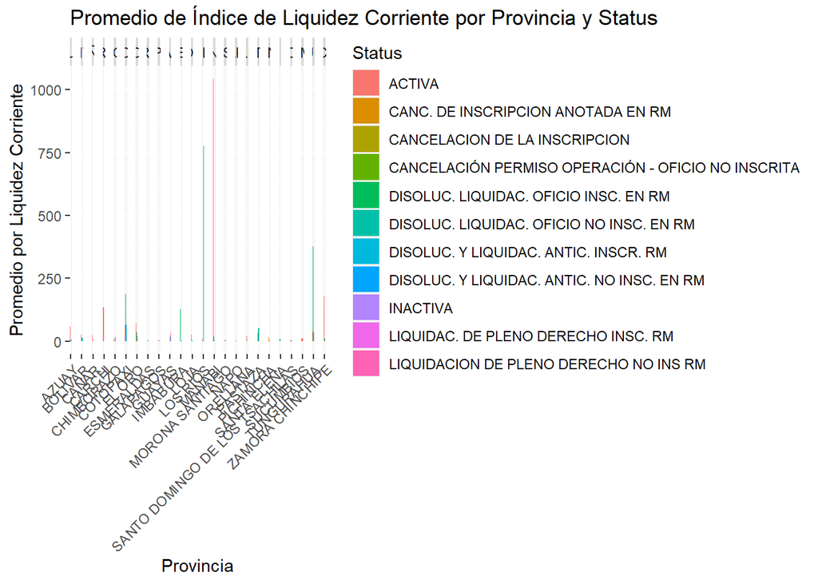

```r
plot(fig0)
```

1.2 Endeudamiento Activo

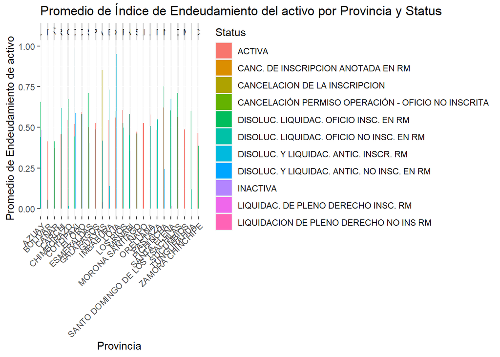

```r
plot(fig1)
```

1.2 Endeudamiento Patrinomial

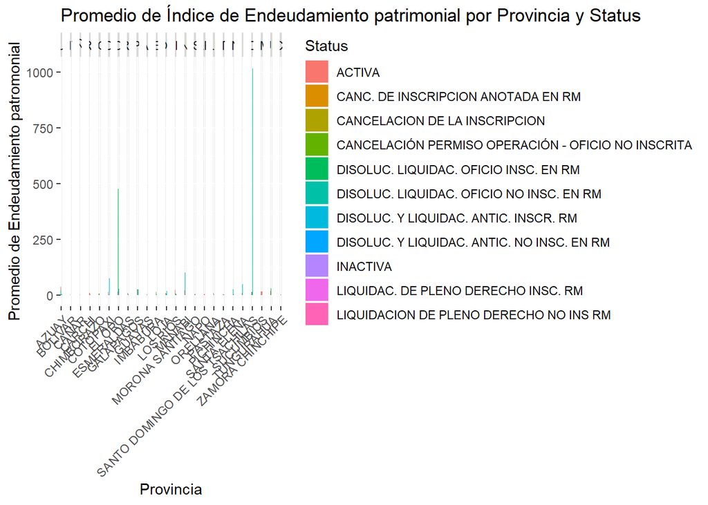

```r
plot(fig2)
```

1.3 Endeudamiento activo fijo

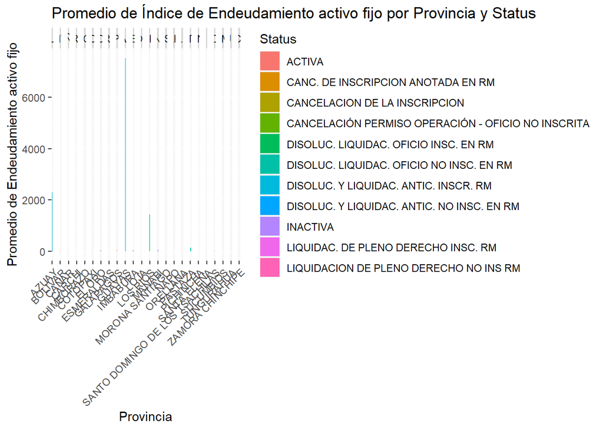

```r
plot(fig3)
```

1.4 Apalancamiento

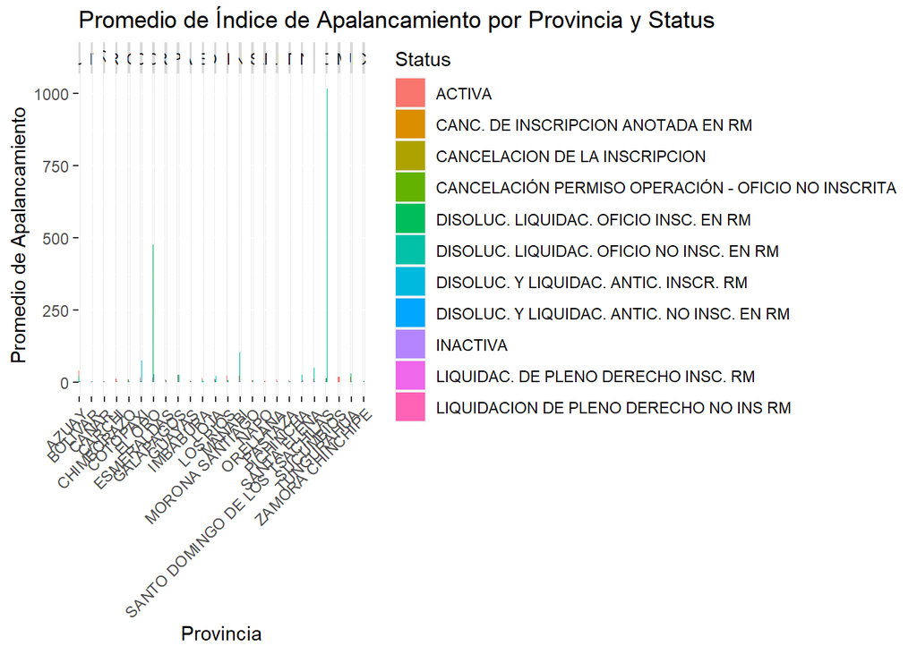

```r
plot(fig4)
```

2. Liquidez y Solvencia por Tipo de Empresa 2.1 Liquidez Corriente

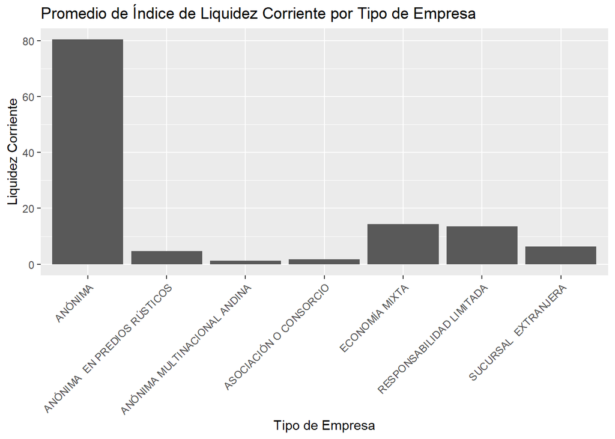

```r
plot(fig5)
```

2.2 Endeudamiento Activo

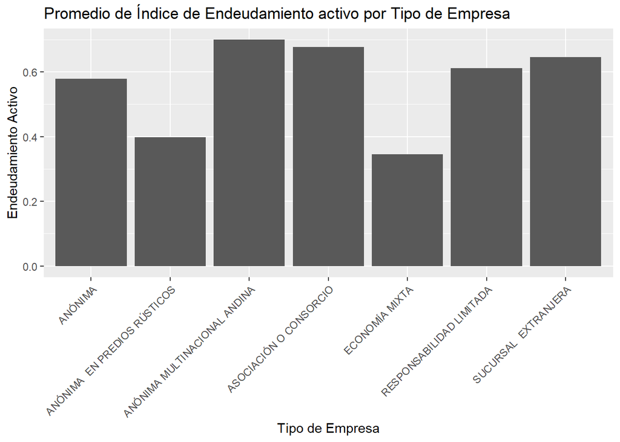

```r
plot(fig6)
```

2.3 Endeudamiento Patrinomial

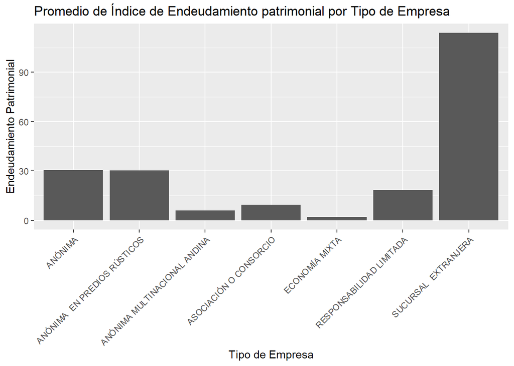

```r
plot(fig7)
```

2.4 Endeudamiento activo fijo

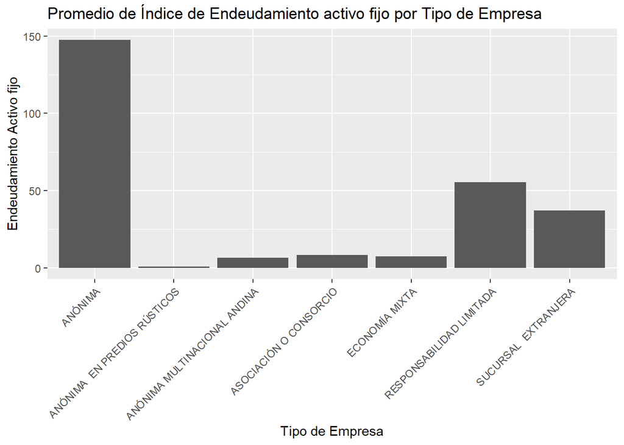

```r
plot(fig8)
```

2.5 Apalancamiento

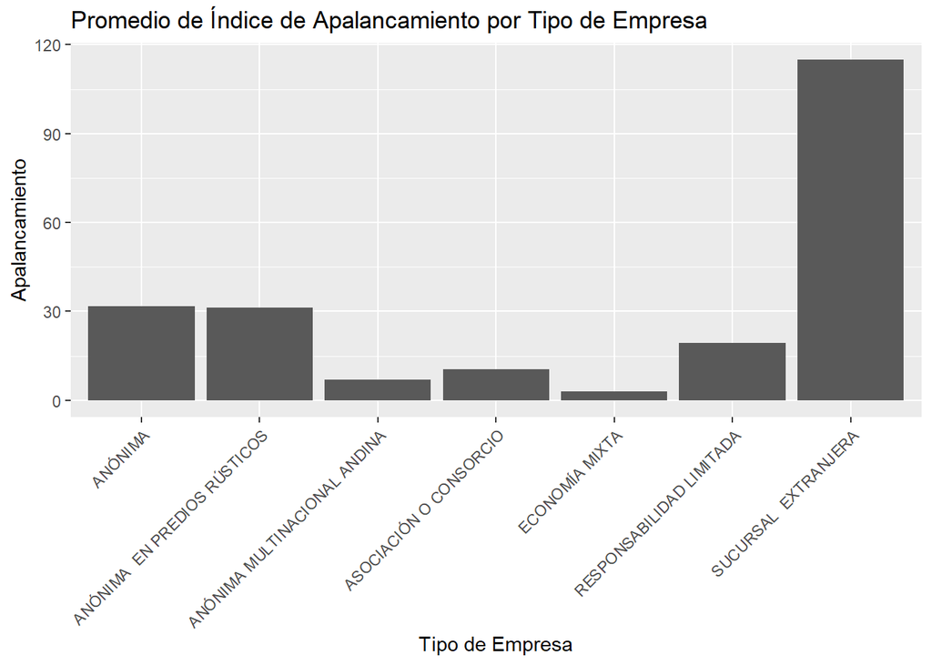

```r
plot(fig9)
```

**Parte 2 - Preguntas de Investigación**